# Sequences

Juan A. Botía

30/07/2019

```r
library(Biostrings)
```

# Dealing with biomart promoters

As our sequence file has no FASTA format, we simply read the content and convert it into a `DNAStringSet` format.

```r
#pp = read.delim("~/Dropbox/sequences/sources.tar/positivePromoters_geneflank",stringsAsFactors=F,sep=",")
pp = read.csv("../Results/badseqs.tsv",
                     stringsAsFactors=F, sep = "\t")
pplist = NULL
for(i in 1:nrow(pp))
  pplist[i] = pp[i,2]

ppset = DNAStringSet(pplist)
cmppset = consensusMatrix(ppset)
```

Now we’ll create the consensus matrix as a quick way of inspecting the sequences. Before that, remember the DNA alphabet used in this package is a IUPAC code http://genome.ucsc.edu/goldenPath/help/iupac.html, as follows

```r
IUPAC_CODE_MAP
```

```
##      A      C      G      T      M      R      W      S      Y      K
##    "A"    "C"    "G"    "T"   "AC"   "AG"   "AT"   "CG"   "CT"   "GT"
##      V      H      D      B      N
##  "ACG"  "ACT"  "AGT"  "CGT" "ACGT"
```

So we can appropriately represent multiple observed alleles in a single sequence.

```r
cmppset = consensusMatrix(ppset)
dim(cmppset)
```

```
## [1]   18 2771
```

```r
cmppset[1:5,1:5]
```

```
##   [,1] [,2] [,3] [,4] [,5]
## A  214  121  120  139  126
## C  102  147  192  166  201
## G  262  220  183  190  166
## T   62  152  145  145  147
## M    0    0    0    0    0
```

```r
#Do we have multiple alleles in any of the sequences? No
if(max(cmppset[-c(1:4),]) > 0){
  cat("Warning. We were expecting simple sequences. They are not\n")
}else{
  cat("All sequences are single DNA sequences\n")
  #We keep only what is useful
  cmppset = cmppset[1:4,]
}
```

```
## All sequences are single DNA sequences
```

Now we can also try interesting representations, as if we use the alphabet frequency

```r
alp = alphabetFrequency(ppset)
alp[1:5,1:5]
```

```
##        A   C   G   T M
## [1,] 160 409 479 171 0
## [2,]  19  81  66  18 0
## [3,]  70 112 122  69 0
## [4,]   9   8   5   2 0
## [5,] 227 282 235 238 0
```

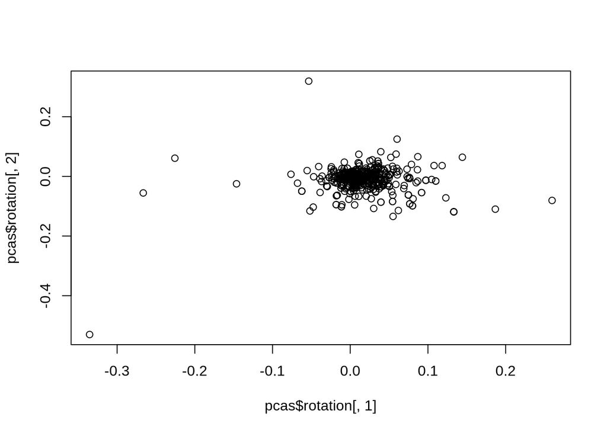

```r
alp = alp[,1:4]
pcas = prcomp(t(alp))
plot(pcas$rotation[,1],pcas$rotation[,2])
```

Now let’s do the same looking for differences between disease promoters and normal ones

```r
alp = alphabetFrequency(ppset)
alp = alp[,1:4]
np = read.csv("../Results/goodseqs.tsv",
                     stringsAsFactors=F, sep = "\t")
nplist = NULL
for(i in 1:nrow(np))
  nplist[i] = np[i,1]


npset = DNAStringSet(nplist)
nalp = alphabetFrequency(npset)
max(nalp[,5:18])
```

```
## [1] 0
```

```r
nalp[1:5,1:5]
```

```
##       A   C   G   T M
## [1,] 10  42  52   7 0
## [2,] 15  23  40   7 0
## [3,] 92 199 126 112 0
## [4,]  4  14  17   7 0
## [5,]  5  10  10   3 0
```

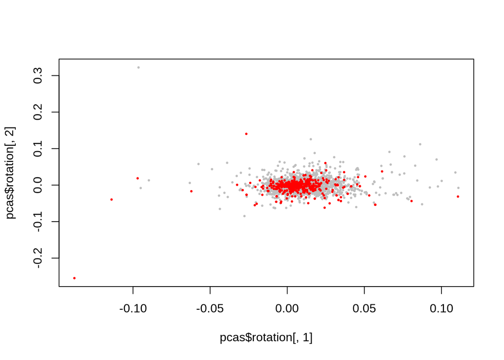

```r
nalp = nalp[,1:4]
aalp = rbind(nalp,alp)

pcas = prcomp(t(aalp))
plot(pcas$rotation[,1],pcas$rotation[,2],pch=19,cex=0.3,
     col=c(rep("grey",nrow(nalp)),rep("red",nrow(alp))))
```

## Trying different k-mers

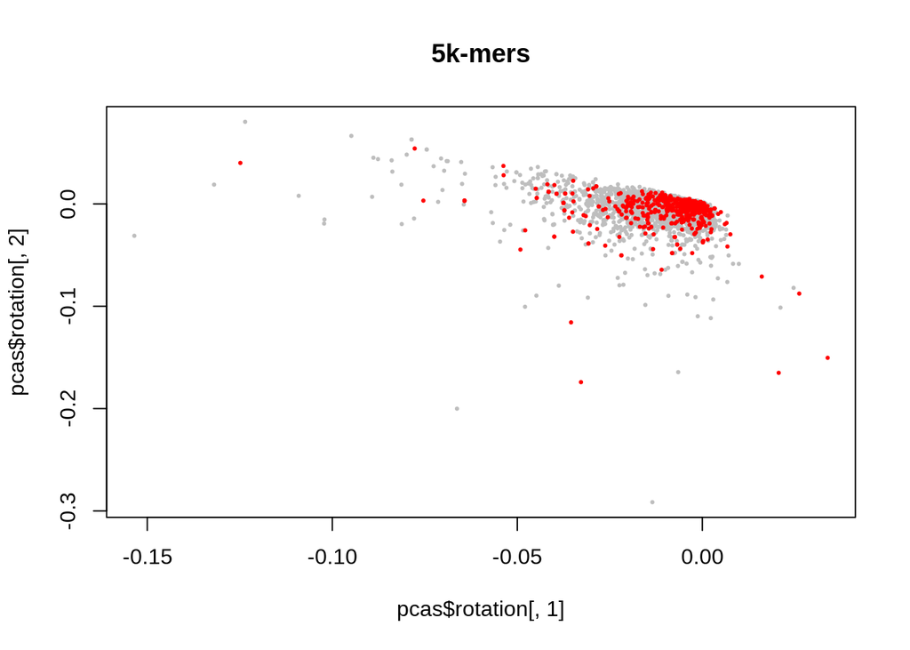

```r
kmers = 5
for(k in kmers){
  alp = oligonucleotideFrequency(ppset,k)
  nalp = oligonucleotideFrequency(npset,k)
  aalp = rbind(nalp,alp)
  pcas = prcomp(t(aalp))
  plot(pcas$rotation[,1],pcas$rotation[,2],pch=19,cex=0.3,
       main=paste0(k,"k-mers"),
     col=c(rep("grey",nrow(nalp)),rep("red",nrow(alp))))
}
```

# References

- This is a good and basic introduction to biostrings https://kasperdanielhansen.github.io/genbioconductor/html/Biostrings.html
- This shows how to manage annotation and sequences simultaneously throug GenomicRanges https://combine-australia.github.io/2017-05-19-bioconductor-melbourne/strings_and_ranges.html
- This may be useful to start working with the notion of k-mers https://cran.r-project.org/web/packages/kmer/vignettes/kmer-vignette.html